# Análisis Trackings

Arena

21 de agosto de 2019

## Variables de localización

| Código_SAP | Zona_de_ventas | ZnVtaCteSo | ZnVtaCteDes | Región | Nombre_Región | conteo |
| --- | --- | --- | --- | --- | --- | --- |
| 18RTDMLE1 | 20006 | USA | USA | NA | NA | 9 |
| 18RTDMME1 | 20006 | USA | USA | NA | NA | 8 |
| 18RTDWME1 | 20006 | USA | USA | NA | NA | 5 |
| 19112A | 20006 | USA | USA | X002 | USA | 1 |
| JCAMLB1 | 20006 | USA | USA | NA | NA | 2 |
| JCAMLE1 | 20006 | USA | USA | NA | NA | 9 |
| JCAMLKACN | 20006 | USA | USA | NA | NA | 8 |
| JCAMLLE1 | 20006 | USA | USA | NA | NA | 7 |
| JCAMOPE1 | 20006 | USA | USA | NA | NA | 3 |
| JCAMSLB1 | 20006 | USA | USA | NA | NA | 3 |
| JCAMSLE1 | 20006 | USA | USA | NA | NA | 3 |
| JCAMWPLE1 | 20006 | USA | USA | NA | NA | 2 |
| JCESGB1 | 20006 | USA | USA | NA | NA | 12 |
| JCESGBCN1 | 20006 | USA | USA | NA | NA | 2 |
| JCESGE1 | 20006 | USA | USA | NA | NA | 7 |
| JCESGECN1 | 20006 | USA | USA | NA | NA | 2 |
| JCESGG1 | 20006 | USA | USA | NA | NA | 13 |
| JCESGI1 | 20006 | USA | USA | NA | NA | 16 |
| JCESGJ1 | 20006 | USA | USA | NA | NA | 4 |
| JCESSB1 | 20006 | USA | USA | NA | NA | 6 |
| JCESSC1 | 20006 | USA | USA | NA | NA | 12 |
| JCESSCCN1 | 20006 | USA | USA | NA | NA | 3 |
| JCESSE1 | 20006 | USA | USA | NA | NA | 4 |
| JCESSI1 | 20006 | USA | USA | NA | NA | 12 |
| JCGMRC1 | 20006 | USA | USA | NA | NA | 4 |
| JCGMRCCN1 | 20006 | USA | USA | NA | NA | 1 |
| JCGMRE1 | 20006 | USA | USA | NA | NA | 7 |
| JCGRMRE1 | 20006 | USA | USA | NA | NA | 3 |
| JCGSMRE1 | 20006 | USA | USA | NA | NA | 2 |
| JCMML1D1 | 20006 | USA | USA | NA | NA | 1 |
| JCMMLD1 | 20006 | USA | USA | NA | NA | 18 |
| JCMMLE2 | 20006 | USA | USA | NA | NA | 4 |
| JCMMPE2 | 20006 | USA | USA | NA | NA | 3 |
| JCMMSE2 | 20006 | USA | USA | NA | NA | 2 |
| XCA19016 | 20006 | USA | USA | X002 | USA | 1 |
| XCA24419 | 20006 | USA | USA | X002 | USA | 1 |
| XCA32617 | 20006 | USA | USA | X002 | USA | 1 |
| XUS081 | 20006 | USA | USA | X002 | USA | 1 |
| XUS124 | 20006 | USA | USA | X002 | USA | 5 |
| XUS19019 | 20006 | USA | USA | X002 | USA | 8 |
| XUS19119 | 20006 | USA | USA | X002 | USA | 1 |
| XUS19216 | 20006 | USA | USA | X002 | USA | 1 |
| XUS19419 | 20006 | USA | USA | X002 | USA | 6 |
| XUS19519 | 20006 | USA | USA | X002 | USA | 5 |
| XUS21319 | 20006 | USA | USA | X002 | USA | 6 |
| XUS23719 | 20006 | USA | USA | X002 | USA | 7 |
| XUS23916A | 20006 | USA | USA | X002 | USA | 2 |
| XUS23919 | 20006 | USA | USA | X002 | USA | 11 |
| XUS24019 | 20006 | USA | USA | X002 | USA | 15 |
| XUS24116 | 20006 | USA | USA | X002 | USA | 13 |
| XUS242A19 | 20006 | USA | USA | X002 | USA | 13 |
| XUS24319 | 20006 | USA | USA | X002 | USA | 14 |
| XUS24419 | 20006 | USA | USA | X002 | USA | 17 |
| XUS24716 | 20006 | USA | USA | X002 | USA | 3 |
| XUS24819 | 20006 | USA | USA | X002 | USA | 6 |
| XUS24919 | 20006 | USA | USA | X002 | USA | 35 |
| XUS27516 | 20006 | USA | USA | X002 | USA | 2 |
| XUS31317 | 20006 | USA | USA | X002 | USA | 5 |
| XUS313CALV19 | 20006 | USA | USA | X002 | USA | 1 |
| XUS319 | 20006 | USA | USA | X002 | USA | 2 |
| XUS321 | 20006 | USA | USA | X002 | USA | 1 |
| XUS324 | 20006 | USA | USA | X002 | USA | 1 |
| XUS32617 | 20006 | USA | USA | X002 | USA | 1 |
| XUS326CALV19 | 20006 | USA | USA | X002 | USA | 1 |
| XUS327 | 20006 | USA | USA | X002 | USA | 1 |
| XUS328 | 20006 | USA | USA | X002 | USA | 2 |
| XUS32817 | 20006 | USA | USA | X002 | USA | 3 |
| XUS32917 | 20006 | USA | USA | X002 | USA | 9 |
| XUS332 | 20006 | USA | USA | X002 | USA | 5 |
| XUS341B | 20006 | USA | USA | X002 | USA | 1 |
| XUS343B | 20006 | USA | USA | X002 | USA | 2 |
| XUS413 | 20006 | USA | USA | X002 | USA | 5 |
| XUS443 | 20006 | USA | USA | X002 | USA | 10 |
| XUS474 | 20006 | USA | USA | X002 | USA | 14 |
| XUS530 | 20006 | USA | USA | X002 | USA | 9 |
| XUS554 | 20006 | USA | USA | X002 | USA | 5 |

A pesar de que pareciera que los catálogos de códigos de **Zona de ventas** y **Región** coinciden, hay conflictos entre las variables **ZnVtaCteSo ZnVtaCteDes** y **Nombre_Región**. Específicamente **PUK**. Eso debe corregirse en SAP asignando al código 20017 en **Zona_de_ventas** la etiqueta JCMD en las variables **ZnVtaCteSo**

| Zona_de_ventas | ZnVtaCteSo | ZnVtaCteDes | Región | Nombre_Región | conteo |
| --- | --- | --- | --- | --- | --- |
| 20006 | USA | USA | X002 | USA | 253 |
| 20006 | USA | USA | NA | NA | 197 |
| 20013 | APAC | APAC | X003 | APAC | 78 |
| 20014 | LATAM | LATAM | X001 | LATAM | 79 |
| 20015 | EMEA | EMEA | X004 | EMEA | 119 |
| 20016 | PUK | PUK | X005 | PUK | 9 |
| 20017 | PUK | PUK | X006 | JCMD | 17 |

## Clientes

Las variables **Cliente24** y **Cliente25** en verdad son 2 variables diferentes? (checar el renglón 4 como ejemplo). Adicionalmente todos los registros de la variable **Cliente Destinatario** asociados a **PROXIMO SPIRITS INC** son en realidad únicos?

| Cliente…24 | Cliente…25 | Cliente_Destinatario…29 | Cliente_Destinatario…30 | conteo |
| --- | --- | --- | --- | --- |
| ALCHEMY WINE & SPIRITS ASIA | NA | 11251 | TRA-SAS | 15 |
| ARCUS NORWAY AS AND OR | NA | 12331 | ARCUS NORWAY AS AND OR | 5 |
| ASAHI BREWERIES LTD | NA | 5986 | ASAHI BREWERIES LTD | 27 |
| AURORA BEBIDAS E ALIMENTOS | FINOS LTDA. | 2461 | AURORA BEBIDAS E ALIMENTOS FINOS LTDA. | 6 |
| AURORA BEBIDAS E ALIMENTOS FINOS | LTDA | 10320 | COMEXPORT TRADING COMERCIO EXTERIOR LTDA | 3 |
| BALLESTER HERMANOS INC | NA | 2075 | BALLESTER HERMANOS INC | 17 |
| BEBIDAS ALCOHOLICAS DEL SUR SAC | NA | 12325 | BEBIDAS ALCOHOLICAS DEL SUR SAC | 3 |
| BRAND CONNECT | ASIA PACIFIC PTE LTD | 12403 | BRAND CONNECT ASIA PACIFIC PTE LTD | 2 |
| BUTLER & SANDS COMPANY LIMITED | NA | 2090 | BUTLER & SANDS COMPANY LIMITED | 7 |
| CASPIRITS LTD | C/O ISBECO LTD. | 2132 | CASPIRITS LTD C/O ISBECO LTD. | 17 |
| DISLICORES SAS | NA | 8928 | DISLICORES SAS | 7 |
| DRINKS HUB ASIA PTE LTD | NA | 11253 | DRINKS HUB ASIA PTE LTD | 4 |
| EGGERS & FRANKE HOLDING GMBH | NA | 10620 | EGGERS & FRANKE HOLDING GMBH C/O KUHNE & NAGEL | 12 |
| ETS ANTOINE MASSOUD SAL | NA | 9506 | ETS ANTOINE MASSOUD SAL | 8 |
| FJ KOREA | NA | 10374 | FJ KOREA | 14 |
| GLOBAL BRANDS NICARAGUA SA | NA | 8831 | GLOBAL BRANDS NICARAGUA SA | 10 |
| GULF BEVERAGES FZE | NA | 7345 | GULF BEVERAGES FZE | 18 |
| GULF BEVERAGES FZE DF | NA | 11721 | GULF BEVERAGES FZE DF | 7 |
| JC MASTER DISTRIBUTION TRADING | NA | 10585 | HANLON TRANSPORT | 10 |
| JC MASTER DISTRIBUTION TRADING | NA | 12497 | PROXIMO AUSTRALIA C/O | 7 |
| KINGS ENTERPRISES NV | NA | 3532 | KINGS ENTERPRISES NV | 7 |
| LION NATHAN WINES AND SPIRITS | NEW ZEALAND LIMITED | 3055 | LION NATHAN WINES AND SPIRITS NEW ZEALAND LIMITED | 10 |
| MASSY DISTRIBUTION TRINIDAD | NA | 2097 | MASSY DISTRIBUTION TRINIDAD | 5 |
| MONTENEGRO SRL | NA | 11060 | MONTENEGRO SRL | 7 |
| PREMIER WINE AND SPIRITS INC | NA | 5967 | PREMIER WINE AND SPIRITS INC | 6 |
| PROXIMO SPIRITS INC | NA | 10079 | PROXIMO SPIRITS INC. / AND OR | 197 |
| PROXIMO SPIRITS INC | NA | 10340 | PROXIMO SPIRITS INC AND OR NWS | 3 |
| PROXIMO SPIRITS INC | NA | 5897 | PROXIMO SPIRITS AND OR | 10 |
| PROXIMO SPIRITS INC | NA | 5911 | PROXIMO SPIRITS INC AND / OR REPUBLIC NATIONAL | 23 |
| PROXIMO SPIRITS INC | NA | 5952 | PROXIMO SPIRITS INC. AND / OR REPUBLIC NATIONAL | 38 |
| PROXIMO SPIRITS INC | NA | 5953 | PROXIMO SPIRITS INC. AND / OR REPUBLIC NATIONAL | 31 |
| PROXIMO SPIRITS INC | NA | 6025 | PROXIMO SPIRITS AND OR | 14 |
| PROXIMO SPIRITS INC | NA | 7021 | PROXIMO SPIRITS INC | 133 |
| PROXIMO SPIRITS INC | NA | 9127 | PROXIMO DISTILLERS LLC | 1 |
| PROXIMO SPIRITS UK LTD | NA | 9466 | PROXIMO SPIRITS UK LTD / OR LONDON CITY BOND LTD GLOBAL WHSE | 9 |
| PT BEVERAGE WORLD LIMITED | NA | 9523 | PT BEVERAGE WORLD LIMITED & SIA EE C/O ATTIKI KINISI LOGISTI | 5 |
| QATAR DISTRIBUTION COMPANY | NA | 3753 | QATAR DISTRIBUTION COMPANY | 14 |
| RETAIL DISTRIBUTION INTL GROUP SRL | NA | 7618 | RETAIL DISTRIBUTION INTL GROUP SRL | 6 |
| ROMAR (FREE ZONE) TRADING CO NV | NA | 2084 | ROMAR (FREE ZONE) TRADING CO NV | 2 |
| ROUST HUNGARY KFT | NA | 10053 | ROUST HUNGARY KFT | 3 |
| SMT PR DUTY FREE INC C/O | NA | 4742 | SMT DUTY FREE, INC. | 6 |
| UNITED BEVERAGES SA | NA | 10422 | UNITED BEVERAGES SA | 2 |
| WALRAVEN SAX | NA | 11295 | BOUW LOGISTIC SERVICES | 6 |
| ZAMORA COMPANY GLOBAL SLU | NA | 10006 | DZ LICORES SLU | 15 |

## Fechas

|  | Fe_Imp.Fact. | Hra_Imp.Fact. |
| --- | --- | --- |
| 141 | 2019-08-16 | 1899-12-31 17:01:03 |
| 142 | 2019-08-16 | 1899-12-31 17:01:03 |
| 143 | 2019-08-16 | 1899-12-31 17:01:03 |
| 144 | 2019-08-16 | 1899-12-31 17:01:03 |
| 145 | 2019-08-16 | 1899-12-31 17:01:03 |
| 146 | 2019-08-16 | 1899-12-31 17:01:03 |
| 147 | 2019-08-16 | 1899-12-31 17:01:03 |
| 148 | 2019-08-16 | 1899-12-31 17:01:03 |
| 149 | 2019-08-16 | 1899-12-31 17:01:03 |
| 150 | 2019-08-16 | 1899-12-31 17:01:03 |

## Coherencia de las fechas

- los **rectángulos** acumulan el **50% de las observaciones**
- la **línea vertical** indica el punto en el que se acumula el 50% de las observaciones, es la **mediana**
- los **bigotes** que se encuentran a los lados nos indican hasta dónde se extienen el resto de las observaciones que podemos considerar como **normales**
- los **puntos aislados** representan a las observaciones **atípicas**.
- los **puntos azules** son las observaciones reales.

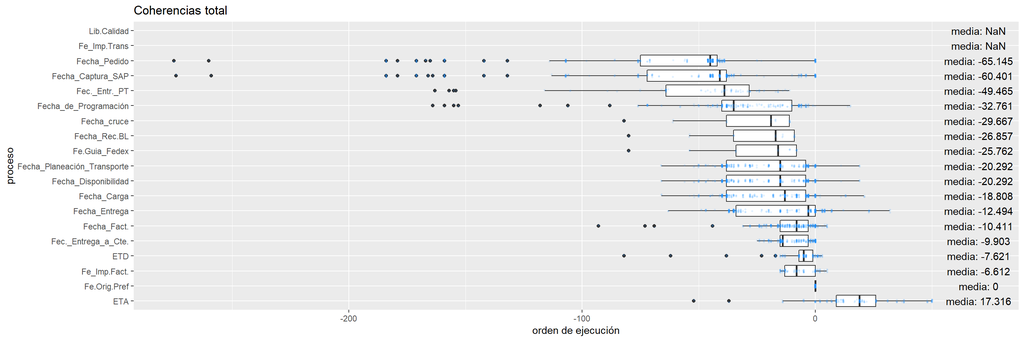

El **principal problema** es la **variabilidad** en los rangos de las fechas de los procesos, un **proceso estandarizado** debería aparecer con **rectángulos pequeños** en la gráfica.

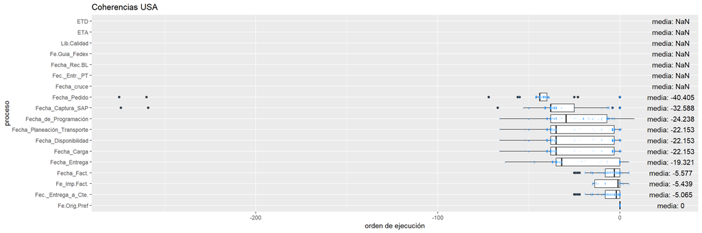

Si centramos los datos de USA alrededor de la fecha preferente de entrega obtenemos algunas observaciones raras

```
##    Pedido_SAP Fecha_Carga Fecha_Disponibilidad Fecha_Pedido Fecha_Captura_SAP Fec._Entrega_a_Cte. Fecha_Entrega Fecha_Planeación_Transporte Fecha_Fact. Fecha_cruce Fecha_de_Programación Fec._Entr._PT
## 1  4700849283          -3                   -3          -44               -38                   0             0                          -3          NA          NA                     8            NA
## 2  4700855411           0                    0            0                 0                   0             3                           0           0          NA                     0            NA
## 3  4700849236          -1                   -1          -44               -38                  -1             2                          -1          -1          NA                    -1            NA
## 4  4700849236          -1                   -1          -44               -38                  -1             2                          -1          -1          NA                    -1            NA
## 5  4700808998          -3                   -3         -260              -259                  -3             0                          -3          -3          NA                    -6            NA
## 6  4700849235          -3                   -3          -44               -38                  -3             0                          -3          -3          NA                    -6            NA
## 7  4700849235          -3                   -3          -44               -38                  -3             0                          -3          -3          NA                    -6            NA
## 8  4700849211          -4                   -4          -42               -37                   0             0                          -4           5          NA                    -7            NA
## 9  4700849211          -4                   -4          -42               -37                   0             0                          -4           5          NA                    -7            NA
## 10 4700849212          -4                   -4          -40               -35                   0             0                          -4           3          NA                    -7            NA
## 11 4700849215          -4                   -4          -41               -36                   0             0                          -4           2          NA                    -7            NA
## 12 4700849269         -38                  -38          -44               -38                  -3           -35                         -38          -3          NA                   -15            NA
## 13 4700849269         -38                  -38          -44               -38                  -3           -35                         -38          -3          NA                   -15            NA
## 14 4700851839         -22                  -22          -23               -22                  -3           -19                         -22          -3          NA                   -22            NA
```

[output cut: 97 more lines]

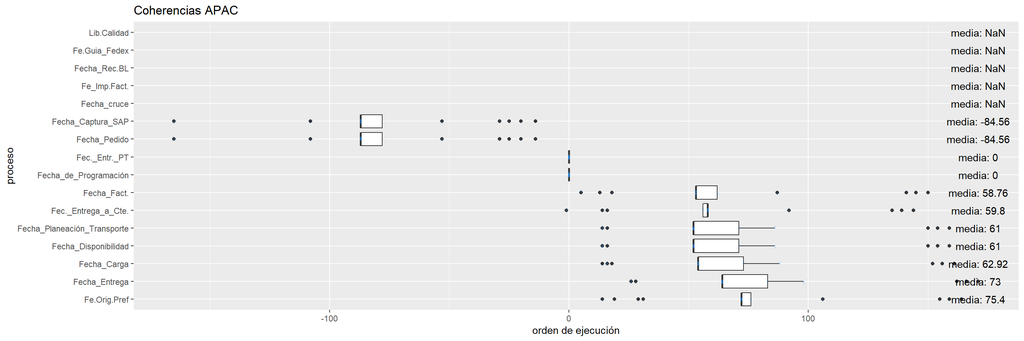

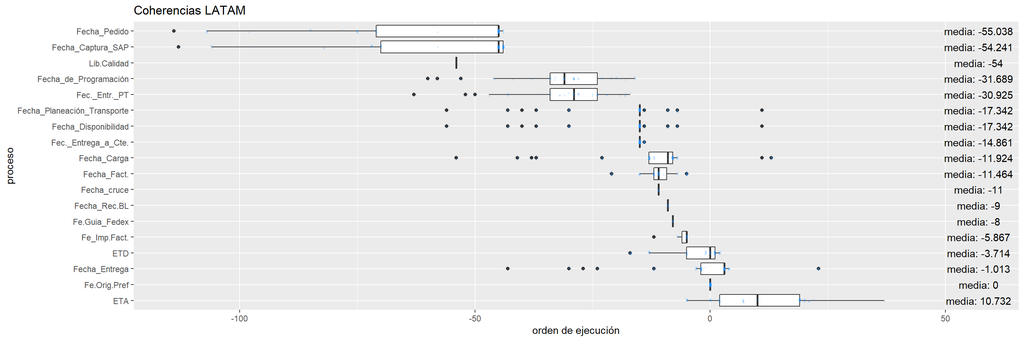

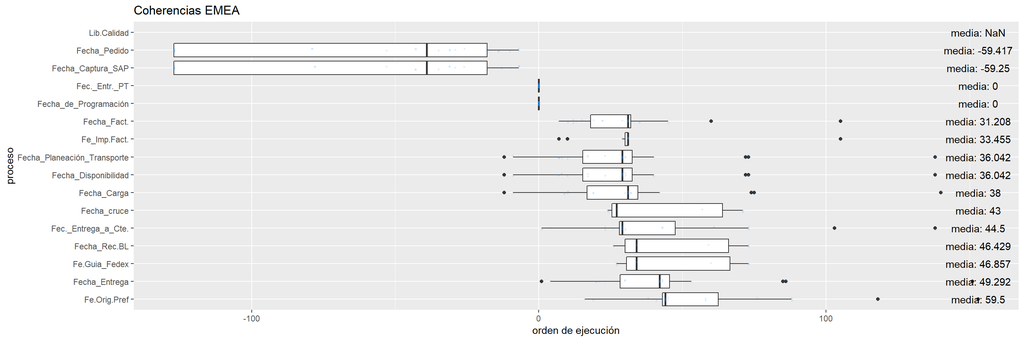

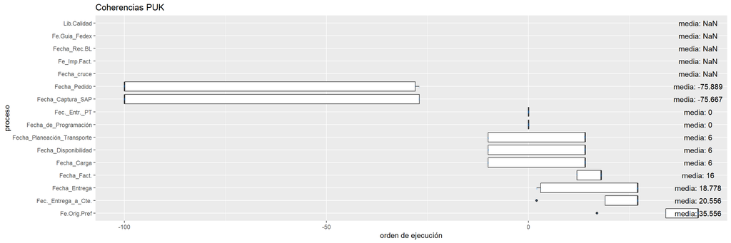

Con lo anterior podemos ver que no todos los procesos se aplican en todas las regiónes

- Fecha cruce
- Fecha de Programación
- Fec. Entr. PT
- Fe Imp.Fact.
- Fecha Rec.BL
- Fe.Guía Fedex
- Fe.Orig.Pref
- Lib.Calidad

```
##   Fecha_Carga         Fecha_Disponibilidad  Fecha_Pedido        Fecha_Captura_SAP    Fec._Entrega_a_Cte.  Fecha_Entrega        Fecha_Planeación_Transporte  Fecha_Fact.          Fecha_cruce
##  Min.   :2019-06-10   Min.   :2019-06-10   Min.   :2018-11-28   Min.   :2018-11-29   Min.   :2019-08-01   Min.   :2019-06-13   Min.   :2019-06-10          Min.   :2019-05-31   Min.   :2019-06-11
##  1st Qu.:2019-07-27   1st Qu.:2019-07-25   1st Qu.:2019-07-01   1st Qu.:2019-07-05   1st Qu.:2019-08-06   1st Qu.:2019-08-02   1st Qu.:2019-07-25          1st Qu.:2019-08-06   1st Qu.:2019-07-26
##  Median :2019-08-07   Median :2019-08-06   Median :2019-07-10   Median :2019-07-12   Median :2019-08-09   Median :2019-08-11   Median :2019-08-06          Median :2019-08-12   Median :2019-08-04
##  Mean   :2019-08-04   Mean   :2019-08-03   Mean   :2019-07-02   Mean   :2019-07-05   Mean   :2019-08-10   Mean   :2019-08-08   Mean   :2019-08-03          Mean   :2019-08-10   Mean   :2019-07-27
##  3rd Qu.:2019-08-16   3rd Qu.:2019-08-14   3rd Qu.:2019-08-06   3rd Qu.:2019-08-07   3rd Qu.:2019-08-15   3rd Qu.:2019-08-19   3rd Qu.:2019-08-14          3rd Qu.:2019-08-16   3rd Qu.:2019-08-11
##  Max.   :2019-09-20   Max.   :2019-09-18   Max.   :2019-08-20   Max.   :2019-08-20   Max.   :2019-08-20   Max.   :2019-10-01   Max.   :2019-09-18          Max.   :2019-08-20   Max.   :2019-08-13
##                                                                                                                                                                                 NA's   :544
##  Fecha_de_Programación Fec._Entr._PT         Fe_Imp.Fact.         Fecha_Rec.BL        Fe.Guia_Fedex         Fe.Orig.Pref        ex_Fecha_Carga ex_Fecha_Disponibilidad ex_Fecha_Pedido
##  Min.   :2019-03-18    Min.   :2019-03-19   Min.   :2019-08-16   Min.   :2019-06-13   Min.   :2019-06-13   Min.   :2019-08-05   Mode:logical   Mode:logical            Mode:logical
##  1st Qu.:2019-07-08    1st Qu.:2019-06-18   1st Qu.:2019-08-16   1st Qu.:2019-07-29   1st Qu.:2019-07-30   1st Qu.:2019-08-15   TRUE:565       TRUE:565                TRUE:565
##  Median :2019-07-22    Median :2019-07-21   Median :2019-08-19   Median :2019-08-06   Median :2019-08-07   Median :2019-08-21
##  Mean   :2019-07-18    Mean   :2019-07-07   Mean   :2019-08-17   Mean   :2019-07-30   Mean   :2019-07-31   Mean   :2019-08-21
##  3rd Qu.:2019-08-02    3rd Qu.:2019-07-26   3rd Qu.:2019-08-19   3rd Qu.:2019-08-13   3rd Qu.:2019-08-14   3rd Qu.:2019-08-29
##  Max.   :2019-09-14    Max.   :2019-08-15   Max.   :2019-08-19   Max.   :2019-08-16   Max.   :2019-08-19   Max.   :2019-09-04
##  NA's   :281           NA's   :479          NA's   :445          NA's   :544          NA's   :544          NA's   :164
##  ex_Fecha_Captura_SAP ex_Fecha_Entrega_Cliente ex_Fecha_Entrega ex_Fecha_Planeacion_Transporte ex_Fecha_Fact  ex_Fecha_Cruce  ex_Fecha_de_Programacion ex_Fecha_entrada_PT ex_Fecha_Impresion_Fact
##  Mode:logical         Mode:logical             Mode:logical     Mode:logical                   Mode:logical   Mode :logical   Mode :logical            Mode :logical       Mode :logical
##  TRUE:565             TRUE:565                 TRUE:565         TRUE:565                       TRUE:565       FALSE:544       FALSE:281                FALSE:479           FALSE:445
##                                                                                                               TRUE :21        TRUE :284                TRUE :86            TRUE :120
##
##
##
##
##  ex_Fecha_BL     ex_Guia_Fedex   ex_Fecha_Original_Preferente  Lib.Calidad  ex_Lib_Calidad
##  Mode :logical   Mode :logical   Mode :logical                Min.   :NA    Mode :logical
##  FALSE:544       FALSE:544       FALSE:164                    1st Qu.:NA    FALSE:565
##  TRUE :21        TRUE :21        TRUE :401                    Median :NA
##                                                               Mean   :NA
##                                                               3rd Qu.:NA
##                                                               Max.   :NA
##                                                               NA's   :565
```

El resumen de procesos por región queda como sigue expresado como porcentaje de los pedidos que tienen información por campo.

| ZnVtaCteSo | Fecha_Pedido | Fecha_Captura_SAP | Fecha_Planeación_Transporte | Fecha_Disponibilidad | Fecha_Carga | Fec._Entrega_a_Cte. | Fecha_Fact. | Fec._Entr._PT | Fecha_Entrega | Fe_Imp.Fact. | Fe.Orig.Pref | Fecha_cruce | Fecha_Rec.BL | Fe.Guia_Fedex | Lib.Calidad |
| --- | --- | --- | --- | --- | --- | --- | --- | --- | --- | --- | --- | --- | --- | --- | --- |
| APAC | 100% | 100% | 100% | 100% | 100% | 100% | 100% | 52.08% | 100% | 0% | 100% | 0% | 0% | 0% | 0% |
| EMEA | 100% | 100% | 100% | 100% | 100% | 100% | 100% | 41.38% | 100% | 29.31% | 100% | 24.14% | 24.14% | 24.14% | 0% |
| LATAM | 100% | 100% | 100% | 100% | 100% | 100% | 100% | 50% | 100% | 26.79% | 100% | 12.5% | 12.5% | 12.5% | 0% |
| PUK | 100% | 100% | 100% | 100% | 100% | 100% | 100% | 75% | 100% | 0% | 100% | 0% | 0% | 0% | 0% |
| USA | 100% | 100% | 100% | 100% | 100% | 100% | 100% | 0% | 100% | 22.51% | 58.06% | 0% | 0% | 0% | 0% |